# Linear Growth of Sensors

Jyotishka Datta

November 4, 2017

### Sensor Data

The sensor data gives us the following information:

G-code Instruction: $GX_k$, the global position based on G-code movement at time $t_k$, and th sensor Measurement: $SX_k$, the global measured position by sensor at time $t_k$.

The time points $t_k$ are not given but we can assume that the time points are $1,2,\ldots,n$, where $n$ is the total number of observations.

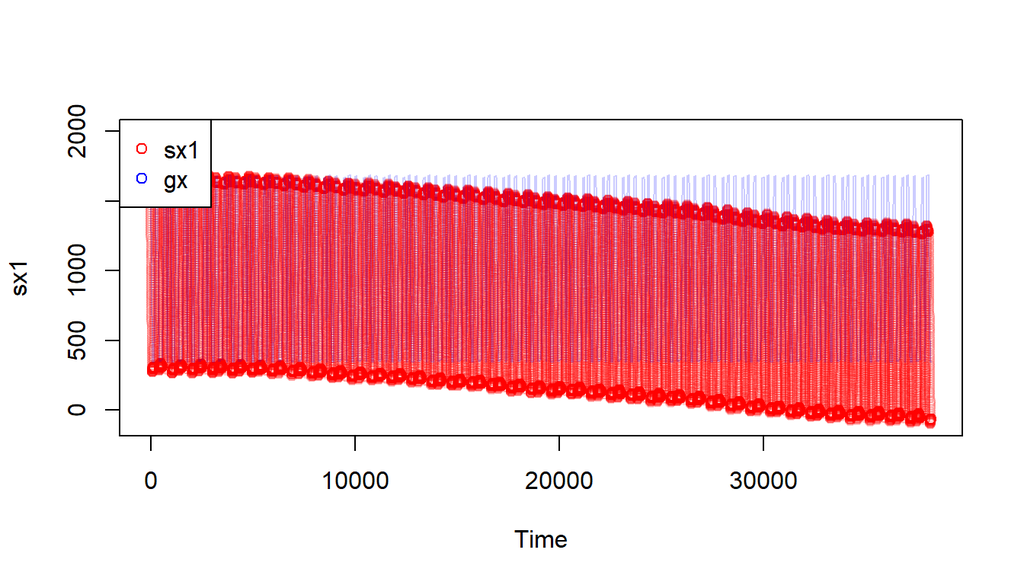

### Linear Growth?

If we have only the G-code but no other sensors, a simple way to model the sensor positional variation would be as a linear combination of G-code position plus a deviation that is a time-dependent random variable. As a linear model, this could be written as:

$$sx_{1k} = \alpha_1 + \beta_1 \times t_k + \gamma_1 \times gx_{1k} + \epsilon_k \\
sy_{1k} = \alpha_2 + \beta_2 \times t_k + \gamma_2 \times gy_{1k} + \nu_k, \; k = 1, \ldots, n.$$

Where the $\alpha_i,\beta_i, \gamma_i$ coefficients are to be estimated from the data fiven. If $\beta_1, \beta_2$ come out as significant, then time has an effect.

```r
m1 <- lm(sx1 ~ Time + gx,data = sensordata)
m2 <- lm(sy1 ~ Time + gy,data = sensordata)

stargazer(m1,m2, omit.stat = c("n", "adj.rsq","rsq"), title="Results from Linear Model", type ='html')
```

**Results from Linear Model**

|  | *Dependent variable:* |  |
| --- | --- | --- |
|  | sx1 | sy1 |
|  | (1) | (2) |
| Time | -0.011*** | -0.007*** |
|  | (0.00001) | (0.00001) |
| gx | 1.013*** |  |
|  | (0.0002) |  |
| gy |  | 1.038*** |
|  |  | (0.0002) |
| Constant | -5.366*** | -8.750*** |
|  | (0.260) | (0.298) |
| Residual Std. Error (df = 38209) | 18.592 | 21.156 |
| F Statistic (df = 2; 38209) | 17,331,703.000*** | 13,714,044.000*** |
| *Note:* | p<0.1; p<0.05; p<0.01 |  |

### Interpretation and de-trending

The summary of the linear model fitted tells us that time is a significant variable for both $sx_1$ and $sy_1$ with a negative trend ($\beta_1 = -0.011$ and $\beta_2 = -0.007$) with very small P-values (as expected). Furthermore, the coefficients of $gx$ and $gy$ are close to 1 (1.013 and 1.038 respectivel).

Now if we want to get back sensor psoitions without the time-dependent trend, we can simply look at
$$\tilde{sx}_{1k} = sx_{1k} - \hat\beta_1 \times t_k \\
\tilde{sy}_{1k} = sy_{1k} - \hat\beta_2 \times t_k$$

These should align well with the g-code - as the following figure shows:

```r
(beta1 = m1$coefficients[2])
```

```
##        Time
## -0.01068947
```

```r
(beta2 = m2$coefficients[2])
```

```
##         Time
## -0.006503953
```

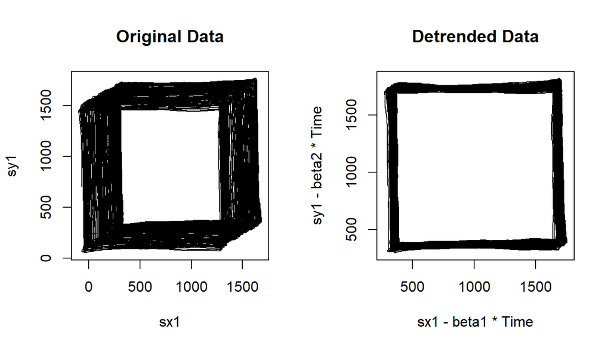

```r
par(mfrow=c(1,2))
plot(sx1,sy1,type="l", main = "Original Data")
plot(sx1-beta1*Time, sy1-beta2*Time, type="l", main = "Detrended Data")
```

**We can possibly use this de-trended series as our new sensor positions. The only change is removing a time component**.

More importantly, this can be done online. We can estimate the time coefficients for a smaller number of observations to de-trend the entire series, or, simply keep track of the time coefficients in an online manner. If it starts getting significance, simply subtract it from the original series.